# Models for Change Detection

## SDT model

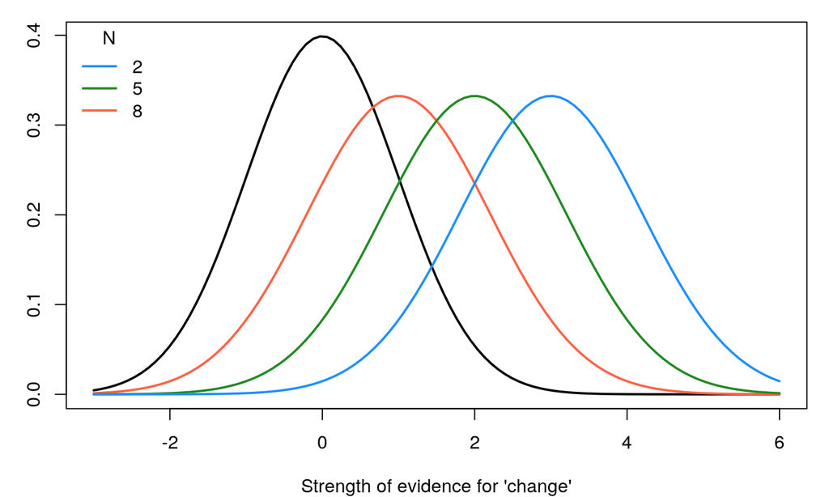

## Implementing these models in R

## Implementing these models in R

We need three elements

- A `function()` to generate the predictions from the models given some parameter settings
- A `function()` to calculate the likelihood of the parameters given the data
- A `function()` that combines the above two into a specific version of the model (e.g. one that restricts certain parameters)

## Implementing these models in R

We need to write this function with an understanding of what form the data are in.

The data are given with one participant per row with numbers of *hits*, *misses*, *false alarms*, and *correct rejections* (order is important) for each set size.

*Note* we only look at the data from the 50% change condition to simplify things.

```r
cd = read.table(file = "data/rouder08-data-0.5.dat")
head(cd, n = 1)
```

```
##   N2_0.5_H N2_0.5_M N2_0.5_Fa N2_0.5_Cr N5_0.5_H N5_0.5_M N5_0.5_Fa
## 1       29        1         1        29       25        5         7
##   N5_0.5_Cr N8_0.5_H N8_0.5_M N8_0.5_Fa N8_0.5_Cr
## 1        23       24        6        11        19
```

## Prediction functions

### Fixed capacity model

With that in mind we make our prediction functions return in the same order

```r
cowan_k <- function(k, a, g, N){
  d = min(1,k/N) # p(probe in memory)

  p = 1:4
  p[1] = a*(d+(1-d)*g)+(1-a)*g # p(hit)
  p[2] = 1-p[1] # p(miss)
  p[3] = a*(1-d)*g+(1-a)*g # p(false-alarm)
  p[4] = 1-p[3] # p(correct rejection)
  return(p)
}
```

## Prediction functions

### Signal detection model

With that in mind we make our prediction functions return in the same order

```r
sdt <- function(d, c, s){
  # this is a simplified version of the sdt
  # model used by rouder et al.
  p = 1:4
  p[1] = pnorm((d - c)/s) # p(hit)
  p[2] = 1 - p[1] # p(miss)
  p[3] = pnorm(- c) # p(false-alarm)
  p[4] = 1 - p[3] # p(correct rejection)
  return(p)
}
```

## Likelihood function

```r
# Multinomial Negative Log-Likelihood
negLL <- function(y,p){
  a=ifelse(y==0 & p==0,0, y*log(p))
  -sum(a)
}
# this seems to work better than dmultinom
```

## Model functions

### Fixed capacity model

```r
N = c(2,5,8)
N_i = rep(1:length(N), each=4) # index

# fixed capacity model
ll.fixed_k <- function(par, y){
  # length(par) == 3 (k, a, g)
  ll=0
  for(i in 1:length(N)){ # for each set size
    p = cowan_k(k = par[1], a = par[2], g = par[3], N = N[i])
    ll = ll + negLL(y[N_i==i], p)
  }
  if(any(c(par < rep(0,3), par > c(max(N),1,1)))){
    ll = ll + 10000 # penalty for going out of range
  }
  return(ll)
}
```

## Model functions

### Variable capacity model

```r
N = c(2,5,8)
N_i = rep(1:length(N), each=4) # index

# variable capacity model
ll.vary_k <- function(par, y){
  # length(par) == 5 (k*3, a, g)
  ll=0
  for(i in 1:length(N)){ # for each set size
    p = cowan_k(k = par[i], a = par[4], g = par[5], N = N[i])
    ll = ll + negLL(y[N_i==i], p)
  }
  if(any(c(par < rep(0,5), par > c(rep(max(N), 3),1,1)))){
    ll = ll + 10000 # penalty for going out of range
  }
  return(ll)
}
```

## Model functions

### Equal-variance signal detection model

```r
N = c(2,5,8)
N_i = rep(1:length(N), each=4) # index

# signal detection model with equal variance for change and no-change items
ll.sdt.ev <- function(par, y){
  # length(par) == 4 (d1, d2, d3, c)
  ll=0
  for(i in 1:length(N)){ # for each set size
    p = sdt(d = par[i], c = par[length(N)+1], s = 1)
    ll = ll + negLL(y[N_i==i], p)
  }
  return(ll)
}
```

## Scripts

`mle-rouder08-group.R` fits these models to aggregate data